# Lecture 14: Model Building

### Day of week effect

Distribution of flight numbers by day-of-week:

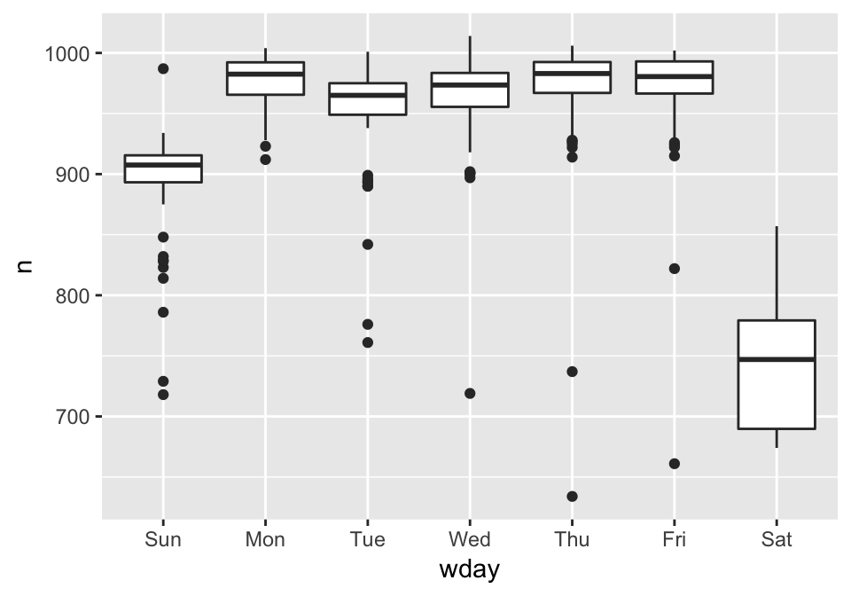

```r
daily <- daily %>%
  mutate(wday = wday(date, label = TRUE))
ggplot(daily, aes(wday, n)) +
  geom_boxplot()
```

There are fewer flights on weekends, esp. Saturdays (why?).

Fit a model to remove this strong pattern:

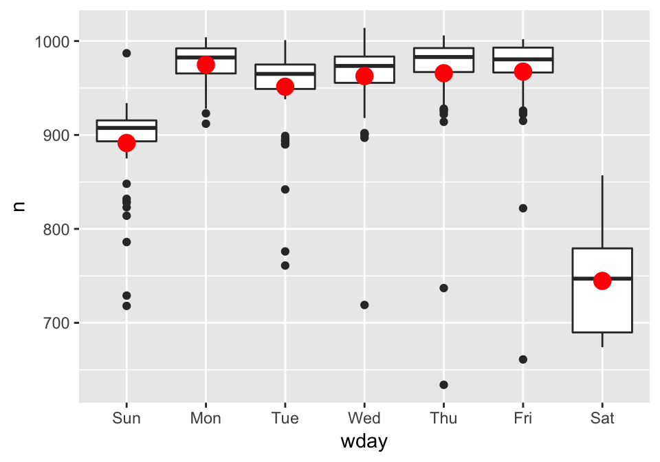

```r
mod <- lm(n ~ wday, data = daily)

grid <- daily %>%
  data_grid(wday) %>%
  add_predictions(mod, "n")

ggplot(daily, aes(wday, n)) +
  geom_boxplot() +
  geom_point(data = grid, colour = "red", size = 4)
```

Next we compute and visualise the residuals:

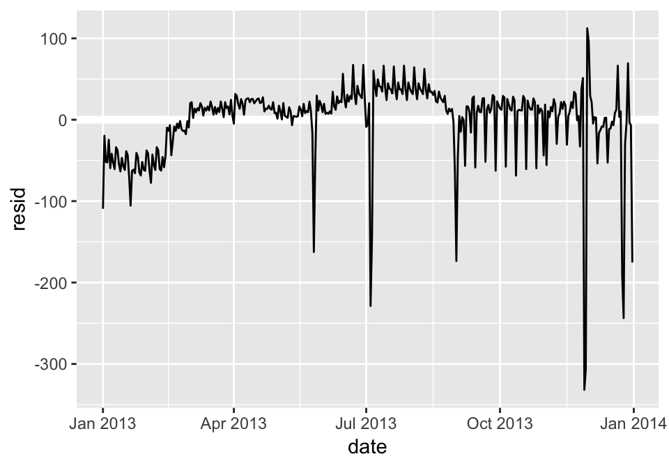

```r
daily <- daily %>%
  add_residuals(mod)
daily %>%
  ggplot(aes(date, resid)) +
  geom_ref_line(h = 0) +
  geom_line()
```

Now we are seeing the deviation from the expected number of flights, given the day of week. Compare this with above.

Some of the subtler patterns still remain:

1. Still a strong regular pattern starting from June. To see why, drawing a plot with one line for each day of the week:

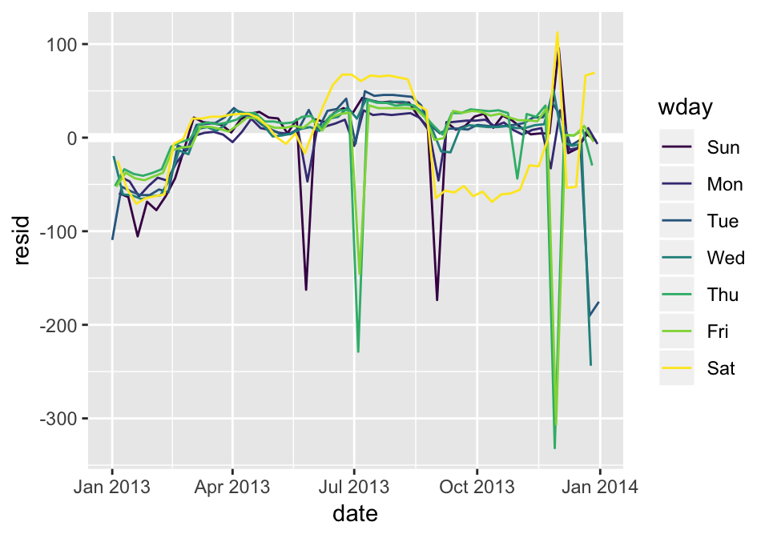

   ```r
   ggplot(daily, aes(date, resid, colour = wday)) +
     geom_ref_line(h = 0) +
     geom_line()
   ```

   Our model fails to accurately predict the number of flights on Saturday: during summer there are more flights than we expect, and during Fall there are fewer.
2. There are some days with far *fewer* flights than expected:

   ```r
   daily %>%
     filter(resid < -100)
   ```

   ```
   ## # A tibble: 11 x 4
   ##    date           n wday  resid
   ##    <date>     <int> <ord> <dbl>
   ##  1 2013-01-01   842 Tue   -109.
   ##  2 2013-01-20   786 Sun   -105.
   ##  3 2013-05-26   729 Sun   -162.
   ##  4 2013-07-04   737 Thu   -229.
   ##  5 2013-07-05   822 Fri   -145.
   ##  6 2013-09-01   718 Sun   -173.
   ##  7 2013-11-28   634 Thu   -332.
   ##  8 2013-11-29   661 Fri   -306.
   ##  9 2013-12-24   761 Tue   -190.
   ## 10 2013-12-25   719 Wed   -244.
   ## 11 2013-12-31   776 Tue   -175.
   ```

   If you’re familiar with American public holidays, you might spot New Year’s day, July 4th, Thanksgiving and Christmas. You’ll work on those in one homework.
3. There seems to be some smoother long term trend over the course of a year.

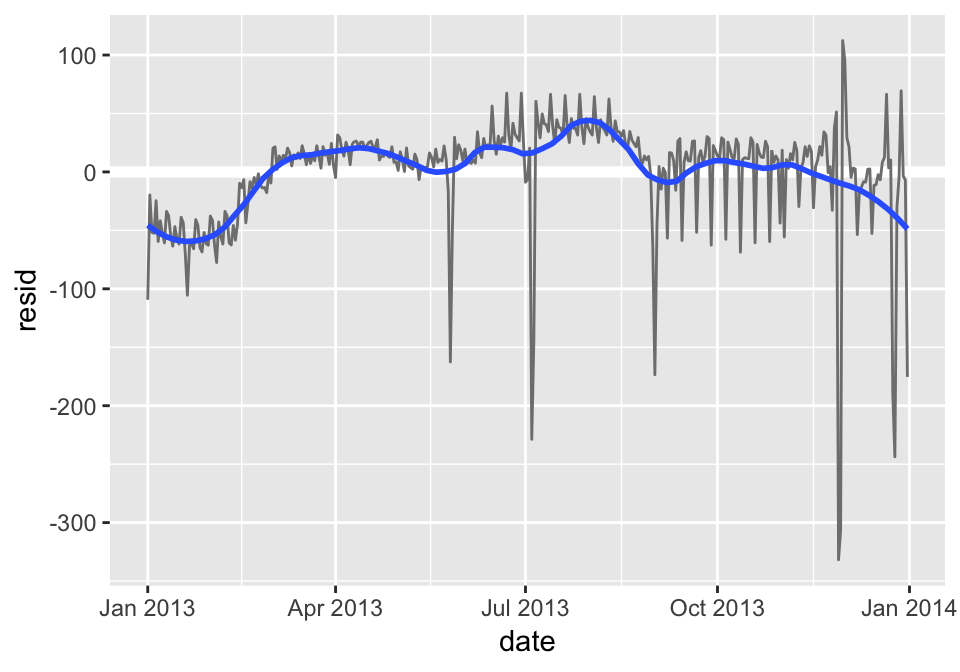

   ```r
   daily %>%
     ggplot(aes(date, resid)) +
     geom_ref_line(h = 0) +
     geom_line(colour = "grey50") +
     geom_smooth(se = FALSE, span = 0.20)
   ```

   There are fewer flights in January (and December), and more in summer (May-Sep). We can’t do much with this pattern quantitatively, because we only have a single year of data. But we can use our domain knowledge to brainstorm potential explanations.

### Seasonal Saturday effect

Go back to the raw numbers, focussing on Saturdays:

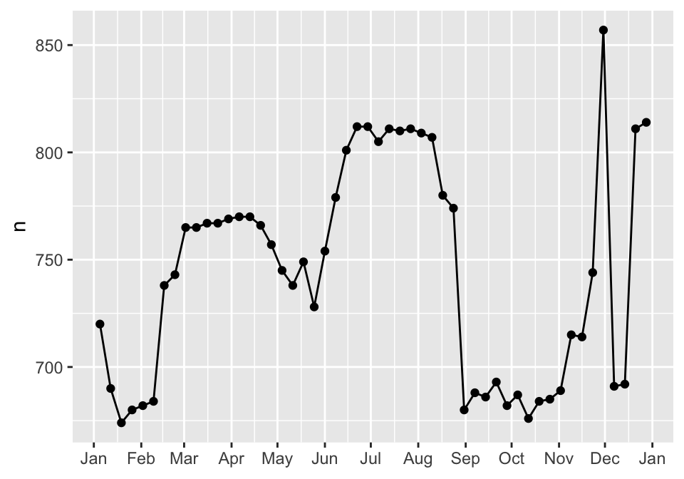

```r
daily %>%
  filter(wday == "Sat") %>%
  ggplot(aes(date, n)) +
    geom_point() +
    geom_line() +
    scale_x_date(NULL, date_breaks = "1 month", date_labels = "%b")
```

This pattern is probably caused by summer holidays: many people go on holiday in the summer, and people don’t mind travelling on Saturdays for vacation. Looking at this plot, we might guess that summer holidays are from early June to late August. That seems to line up fairly well with the [New York state’s school terms](http://schools.nyc.gov/Calendar/2013-2014+School+Year+Calendars.htm): summer break in 2013 was Jun 26–Sep 9.

(Then why are there more Saturday flights in the Spring than the Fall?)

Create a “term” variable that roughly captures the three school terms, and check with a plot:

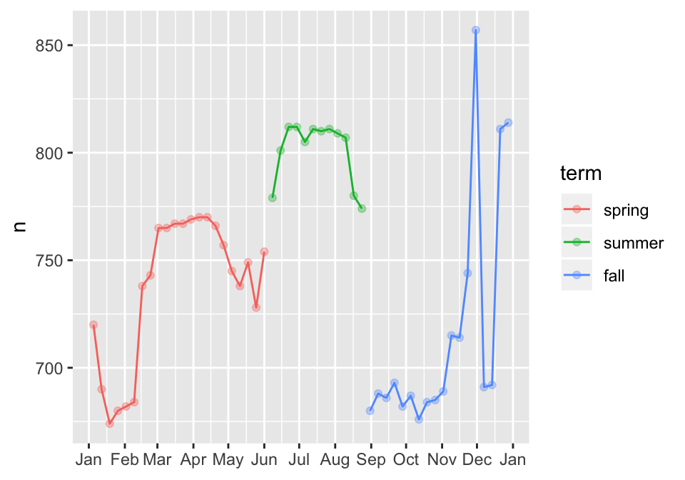

```r
term <- function(date) {
  cut(date,
    breaks = ymd(20130101, 20130605, 20130825, 20140101),
    labels = c("spring", "summer", "fall")
  )
}

daily <- daily %>%
  mutate(term = term(date))

daily %>%
  filter(wday == "Sat") %>%
  ggplot(aes(date, n, colour = term)) +
  geom_point(alpha = 1/3) +
  geom_line() +
  scale_x_date(NULL, date_breaks = "1 month", date_labels = "%b")
```

Distribution of flight numbers by day-of-week, for each term:

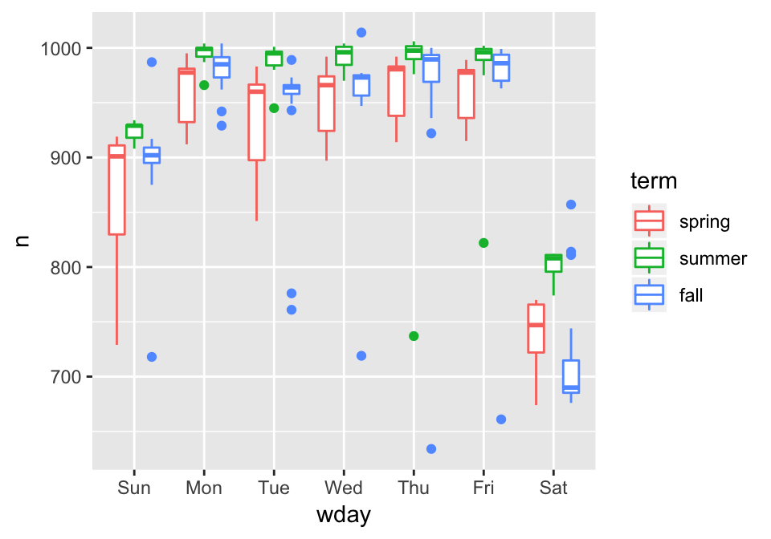

```r
daily %>%
  ggplot(aes(wday, n, colour = term)) +
    geom_boxplot()
```

It looks like there is significant variation across the terms, so fitting a separate day of week effect for each term is reasonable.

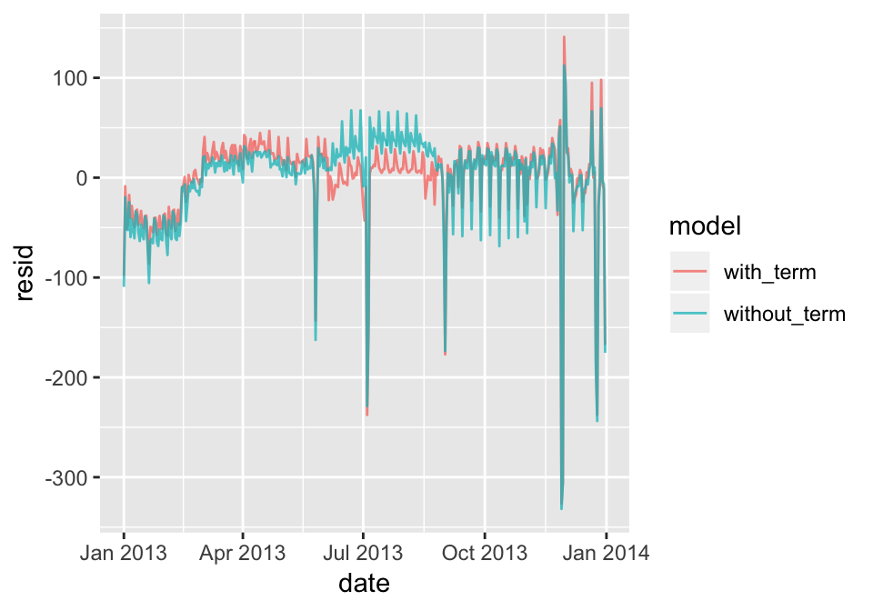

```r
mod1 <- lm(n ~ wday, data = daily)
mod2 <- lm(n ~ wday * term, data = daily)

daily %>%
  gather_residuals(without_term = mod1, with_term = mod2) %>%
  ggplot(aes(date, resid, colour = model)) +
    geom_line(alpha = 0.75)
```

This improves our model, but we can still spot the day of week effect.

Overlay the predictions from the model on to the raw data:

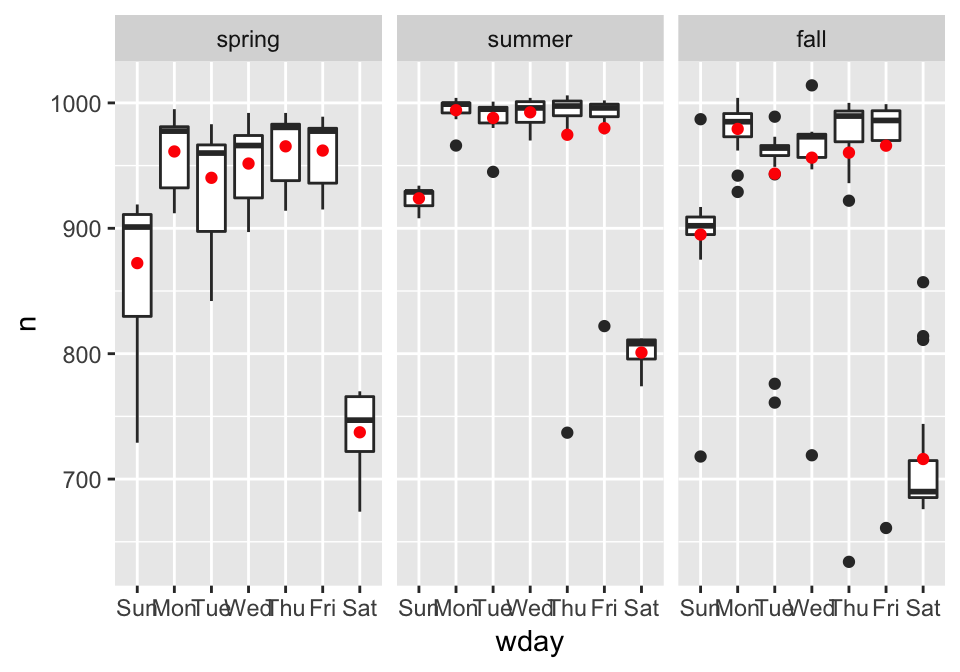

```r
grid <- daily %>%
  data_grid(wday, term) %>%
  add_predictions(mod2, "n")

ggplot(daily, aes(wday, n)) +
  geom_boxplot() +
  geom_point(data = grid, colour = "red") +
  facet_wrap(~ term)
```

We have a lot of big outliers (especially in the fall); use a model that is robust to the effect of outliers:

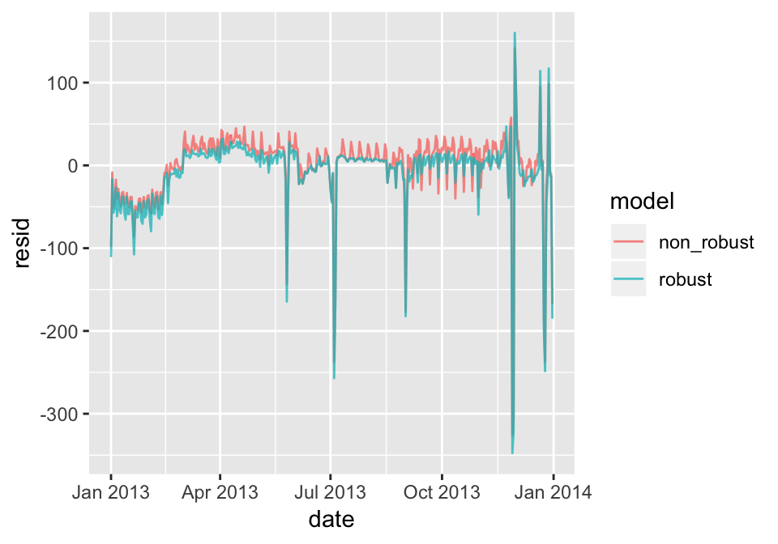

```r
mod3 <- MASS::rlm(n ~ wday * term, data = daily)

daily %>%
  gather_residuals(non_robust = mod2, robust = mod3) %>%
  ggplot(aes(date, resid, colour = model)) +
    geom_line(alpha = 0.75)
```

Now the day of week effect is quite small. It’s now much easier to see the positive and negative outliers, and the long-term trend.

### Time of year: an alternative approach

Insteas of applying our domain knowledge (how the US school term affects travel) to improve the linear model, we could use a more flexible model and allow that to capture the pattern we’re interested in:

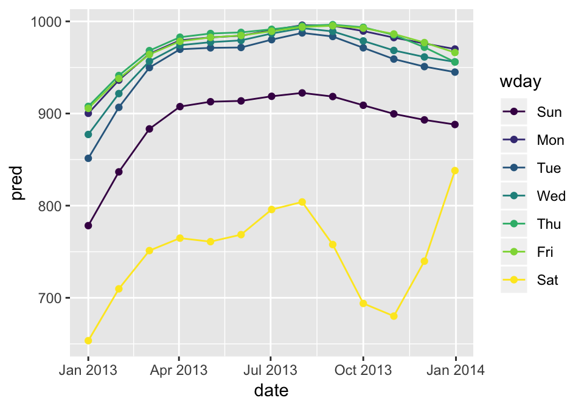

```r
library(splines)
mod <- MASS::rlm(n ~ wday * ns(date, 5), data = daily)

daily %>%
  data_grid(wday, date = seq_range(date, n = 13)) %>%
  add_predictions(mod) %>%
  ggplot(aes(date, pred, colour = wday)) +
    geom_line() +
    geom_point()
```

We see a strong pattern in the numbers of Saturday flights. This is reassuring, because we also saw that pattern in the raw data. It’s a good sign when you get the same signal from different approaches.